# Customer Behavior Analysis

## Introduction

Understanding customer purchasing behavior helps businesses improve marketing strategies, increase sales, and enhance customer satisfaction.

The goal is to extract meaningful insights that can help businesses make better decisions regarding customer targeting and retention.

```python
# Import required libraries
import pandas as pd
import numpy as np
import matplotlib.pyplot as plt
import seaborn as sns

# Display plots inside the notebook
%matplotlib inline
```

```python
df = pd.read_csv("D:\projects\InternSpark_Projects\Task_1\ecommerce_customer_data_large.csv")
```

```python
df.head()
```

|  | Customer ID | Purchase Date | Product Category | Product Price | Quantity | Total Purchase Amount | Payment Method | Customer Age | Returns | Customer Name | Age | Gender | Churn |
| --- | --- | --- | --- | --- | --- | --- | --- | --- | --- | --- | --- | --- | --- |
| 0 | 44605 | 2023-05-03 21:30:02 | Home | 177 | 1 | 2427 | PayPal | 31 | 1.0 | John Rivera | 31 | Female | 0 |
| 1 | 44605 | 2021-05-16 13:57:44 | Electronics | 174 | 3 | 2448 | PayPal | 31 | 1.0 | John Rivera | 31 | Female | 0 |
| 2 | 44605 | 2020-07-13 06:16:57 | Books | 413 | 1 | 2345 | Credit Card | 31 | 1.0 | John Rivera | 31 | Female | 0 |
| 3 | 44605 | 2023-01-17 13:14:36 | Electronics | 396 | 3 | 937 | Cash | 31 | 0.0 | John Rivera | 31 | Female | 0 |
| 4 | 44605 | 2021-05-01 11:29:27 | Books | 259 | 4 | 2598 | PayPal | 31 | 1.0 | John Rivera | 31 | Female | 0 |

```python
df.columns
```

```
Index(['Customer ID', 'Purchase Date', 'Product Category', 'Product Price',
       'Quantity', 'Total Purchase Amount', 'Payment Method', 'Customer Age',
       'Returns', 'Customer Name', 'Age', 'Gender', 'Churn'],
      dtype='object')
```

```python
df.info()
```

```
<class 'pandas.core.frame.DataFrame'>
RangeIndex: 250000 entries, 0 to 249999
Data columns (total 13 columns):
 #   Column                 Non-Null Count   Dtype
---  ------                 --------------   -----
 0   Customer ID            250000 non-null  int64
 1   Purchase Date          250000 non-null  object
 2   Product Category       250000 non-null  object
 3   Product Price          250000 non-null  int64
 4   Quantity               250000 non-null  int64
 5   Total Purchase Amount  250000 non-null  int64
 6   Payment Method         250000 non-null  object
 7   Customer Age           250000 non-null  int64
 8   Returns                202618 non-null  float64
 9   Customer Name          250000 non-null  object
 10  Age                    250000 non-null  int64
 11  Gender                 250000 non-null  object
 12  Churn                  250000 non-null  int64
dtypes: float64(1), int64(7), object(5)
memory usage: 24.8+ MB
```

```python
df.shape
```

```
(250000, 13)
```

```python
# Check missing values
df.isnull().sum()
```

```
Customer ID                  0
Purchase Date                0
Product Category             0
Product Price                0
Quantity                     0
Total Purchase Amount        0
Payment Method               0
Customer Age                 0
Returns                  47382
Customer Name                0
Age                          0
Gender                       0
Churn                        0
dtype: int64
```

```python
# Check duplicate rows
df.duplicated().sum()
```

```
np.int64(0)
```

```python
# Convert Purchase Date to datetime

df['Purchase Date'] = pd.to_datetime(df['Purchase Date'])
```

### Converting Date Column

The purchase date column is converted into datetime format to allow time-based analysis such as recency calculation and purchase trends.

```python
# Fill missing return values with 0 (assuming no return)

df['Returns'] = df['Returns'].fillna(0)
```

### Handling Missing Values

The 'Returns' column contains missing values. These are replaced with 0, assuming that missing values indicate that no return was made.

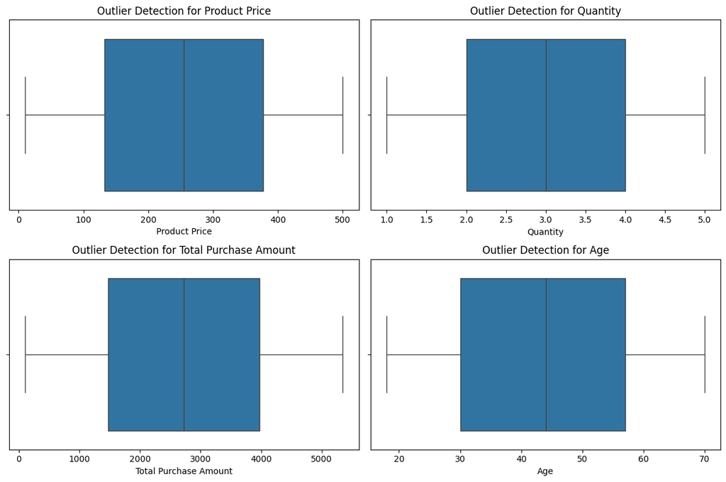

```python
# Checking Outliers using Boxplots

numeric_columns = ['Product Price', 'Quantity', 'Total Purchase Amount', 'Age']

plt.figure(figsize=(12,8))

for i, col in enumerate(numeric_columns,1):
    plt.subplot(2,2,i)
    sns.boxplot(x=df[col])
    plt.title(f'Outlier Detection for {col}')

plt.tight_layout()
plt.show()
```

### Outlier Detection

Outliers are extreme values that differ significantly from other observations in the dataset. These unusual values can distort statistical analysis and machine learning models.

In this step, we use **boxplots** to visually detect outliers in key numerical columns such as:

- Product Price
- Quantity
- Total Purchase Amount
- Age

Boxplots help identify outliers using the **Interquartile Range (IQR) method**, where values outside the whiskers may represent unusually high or low observations.

Detecting outliers helps analysts decide whether to remove, transform, or keep them depending on the business context.

```python
# Detecting outliers using IQR method

Q1 = df[numeric_columns].quantile(0.25)
Q3 = df[numeric_columns].quantile(0.75)

IQR = Q3 - Q1

outliers = ((df[numeric_columns] < (Q1 - 1.5 * IQR)) |
            (df[numeric_columns] > (Q3 + 1.5 * IQR)))

outliers.sum()
```

```
Product Price            0
Quantity                 0
Total Purchase Amount    0
Age                      0
dtype: int64
```

## Data Cleaning

Data cleaning is an important step in the data analysis process. It ensures that the dataset is accurate, consistent, and ready for analysis.

The following data cleaning steps were performed:

### 1. Handling Missing Values

The dataset contained missing values in the **Returns** column. These missing values were replaced with **0**, assuming that missing entries indicate that no product was returned.

### 2. Date Conversion

The **Purchase Date** column was converted into datetime format to allow time-based analysis such as monthly trends and recency calculations.

### 3. Duplicate Check

The dataset was checked for duplicate rows using the `duplicated()` function. No duplicate records were found.

### 4. Outlier Detection

Outliers were identified using **boxplots** and the **Interquartile Range (IQR) method** for numerical columns. Detecting outliers helps ensure that extreme values do not distort the analysis.

```python
# Create Total Revenue column

df['Revenue'] = df['Product Price'] * df['Quantity']

# Extract year and month for trend analysis

df['Year'] = df['Purchase Date'].dt.year
df['Month'] = df['Purchase Date'].dt.month
```

### Feature Engineering

New features were created to improve analysis:

Revenue = Product Price × Quantity  
Year and Month extracted from Purchase Date to analyze purchase trends.

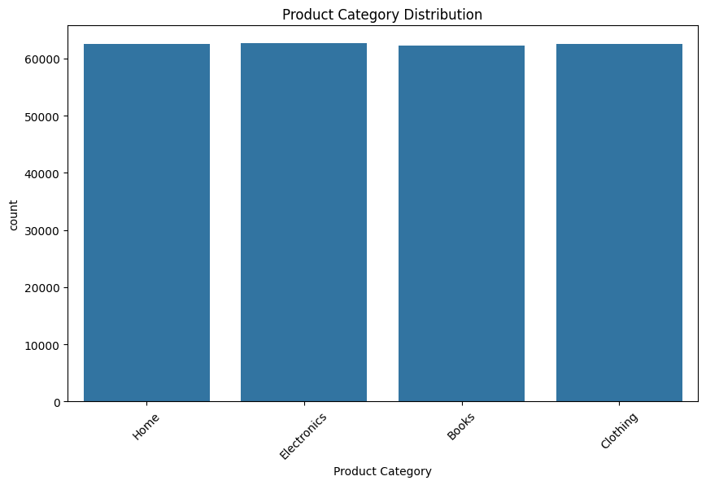

```python
import seaborn as sns
import matplotlib.pyplot as plt

plt.figure(figsize=(10,6))
sns.countplot(data=df, x='Product Category')
plt.title("Product Category Distribution")
plt.xticks(rotation=45)
plt.show()
```

### Insight: Product Category Distribution

The bar chart illustrates the frequency of purchases across different product categories in the dataset.

From the visualization, we can identify which product categories are purchased more frequently by customers. Categories with higher counts indicate stronger customer demand and popularity among shoppers.

Analyzing product category distribution helps businesses understand customer preferences and identify which product segments contribute the most to sales activity. This insight can support better inventory planning, targeted promotions, and product development strategies.

### Business Insight

The product category distribution highlights the relative popularity of different product categories among customers. Categories with the highest purchase counts represent the most frequently demanded products.

Understanding which categories attract the most customer interest allows businesses to optimize inventory management, prioritize high-performing product segments, and design targeted marketing campaigns to further boost sales in popular categories.

[figure not shown]

```python
plt.figure(figsize=(8,6))
sns.countplot(data=df, x='Payment Method')
plt.title("Payment Method Usage")
plt.show()
```

### Insight: Payment Method Usage

The chart shows the distribution of different payment methods used by customers during transactions.

From this visualization, we can observe which payment methods are most frequently preferred by customers. A higher count for a specific payment method indicates stronger customer preference and convenience associated with that option.

Understanding payment method preferences helps businesses optimize their checkout process, improve payment system reliability, and ensure that the most popular payment options are easily accessible to customers.

### Business Insight

The payment method distribution highlights how customers prefer to complete their purchases.

Identifying the most commonly used payment methods helps businesses improve customer experience by ensuring smooth and secure payment processing for preferred options. Additionally, understanding these preferences can guide businesses in integrating new payment technologies or optimizing existing ones to enhance customer satisfaction and transaction efficiency.

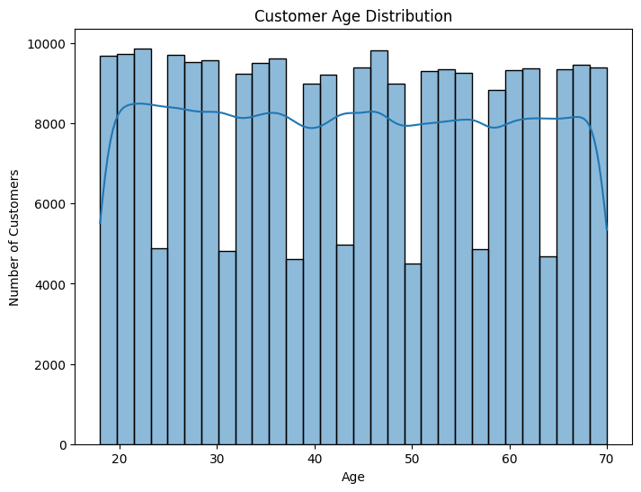

```python
plt.figure(figsize=(8,6))
sns.histplot(df['Age'], bins=30, kde=True)

plt.title("Customer Age Distribution")
plt.xlabel("Age")
plt.ylabel("Number of Customers")

plt.show()
```

### Insight: Customer Age Distribution

The histogram illustrates the distribution of customers across different age groups. The KDE (Kernel Density Estimate) curve provides a smooth representation of the age distribution pattern.

Understanding the age distribution allows businesses to tailor marketing campaigns, product offerings, and promotional strategies toward the most active age groups, thereby improving customer engagement and sales performance.

### Business Insight

The customer age distribution reveals the demographic composition of the customer base. The KDE curve highlights the density of customers across different age groups.

If a significant portion of customers falls within a specific age range, businesses can focus their marketing strategies and product positioning to better serve that demographic segment. This insight is useful for designing targeted advertisements, personalized promotions, and age-specific product recommendations.

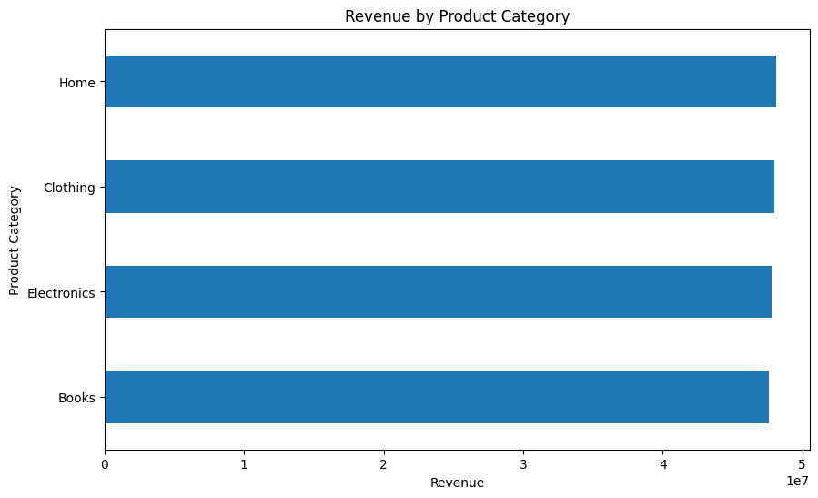

```python
category_revenue = df.groupby('Product Category')['Revenue'].sum().sort_values()

plt.figure(figsize=(10,6))
category_revenue.plot(kind='barh')
plt.title("Revenue by Product Category")
plt.xlabel("Revenue")
plt.show()
```

### Insight: Revenue by Product Category

The horizontal bar chart illustrates the total revenue generated by each product category.

From the visualization, we can identify which product categories contribute the most to overall revenue. Categories with higher revenue indicate strong customer demand and purchasing activity, while categories with lower revenue may require improved marketing strategies or promotional efforts.

This analysis helps businesses prioritize high-performing product categories and allocate resources effectively to maximize profitability.

### Business Insight

The chart shows the total revenue generated by each product category. It highlights which product segments are the most profitable for the business.

High-revenue categories indicate strong customer demand and purchasing frequency, suggesting that these products play a major role in driving overall sales. On the other hand, lower-performing categories may require improved marketing strategies, discounts, or product positioning.

Understanding category-level revenue performance helps businesses optimize inventory management, marketing campaigns, and product development strategies.

## Exploratory Data Analysis (EDA)

Exploratory Data Analysis (EDA) is an essential step in the data analysis process used to understand the structure, patterns, and key characteristics of the dataset.

In this stage, several visualizations were created to explore customer purchasing behavior, product category distribution, payment method preferences, and demographic patterns such as customer age distribution.

These analyses help reveal important trends, customer preferences, and sales patterns that can support data-driven business decisions.

The next step is to analyze the **relationships between numerical variables using correlation analysis**, which helps identify how different features influence each other.

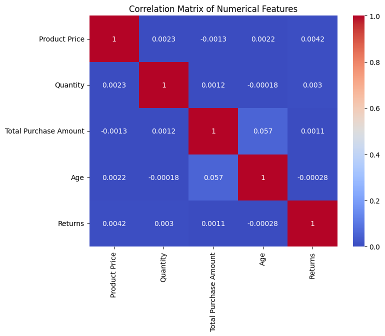

```python
# Correlation matrix

correlation_matrix = df[['Product Price','Quantity','Total Purchase Amount','Age','Returns']].corr()

plt.figure(figsize=(8,6))
sns.heatmap(correlation_matrix, annot=True, cmap='coolwarm')

plt.title("Correlation Matrix of Numerical Features")
plt.show()
```

### Insight

The correlation heatmap shows the strength of relationships between numerical variables.

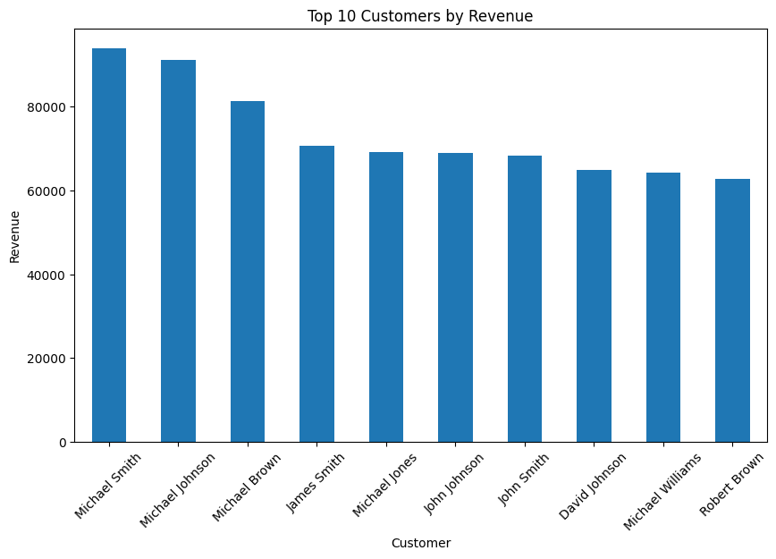

```python
top_customers = df.groupby('Customer Name')['Revenue'].sum().sort_values(ascending=False).head(10)

plt.figure(figsize=(10,6))
top_customers.plot(kind='bar')

plt.title("Top 10 Customers by Revenue")
plt.xlabel("Customer")
plt.ylabel("Revenue")
plt.xticks(rotation=45)
plt.show()
```

### Insight: Top 10 Customers by Revenue

The bar chart shows the top 10 customers who have generated the highest total revenue for the business.

Identifying top revenue-generating customers is important for businesses because these customers play a major role in driving profitability. Companies can focus on retaining these customers by offering loyalty programs, personalized discounts, and exclusive offers to maintain long-term engagement and maximize customer lifetime value.

### Business Interpretation

Businesses should prioritize maintaining strong relationships with these high-value customers through targeted marketing campaigns, loyalty rewards, and personalized experiences to ensure long-term retention and sustained revenue growth.

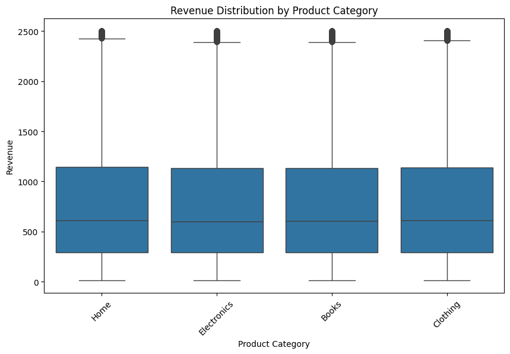

```python
plt.figure(figsize=(10,6))

sns.boxplot(data=df, x='Product Category', y='Revenue')

plt.title("Revenue Distribution by Product Category")
plt.xticks(rotation=45)
plt.show()
```

### Insight: Revenue Distribution by Product Category

The boxplot visualizes the distribution of revenue across different product categories. It shows the median revenue, interquartile range, and potential outliers for each category.

From the visualization, we can observe how revenue varies among different product categories. Categories with higher median values indicate stronger revenue generation, while wider boxes suggest greater variability in customer spending within that category.

This analysis helps identify which product categories consistently generate higher revenue and which categories experience more variation in purchase amounts.

### Business Interpretation

Understanding the revenue distribution across product categories allows businesses to evaluate the performance and consistency of different product segments.

Categories with higher median revenue and stable distribution may represent reliable revenue drivers for the business. On the other hand, categories with high variability or outliers may indicate occasional high-value purchases or inconsistent demand.

These insights can help businesses optimize inventory planning, pricing strategies, and targeted marketing efforts to maximize revenue from high-performing product categories.

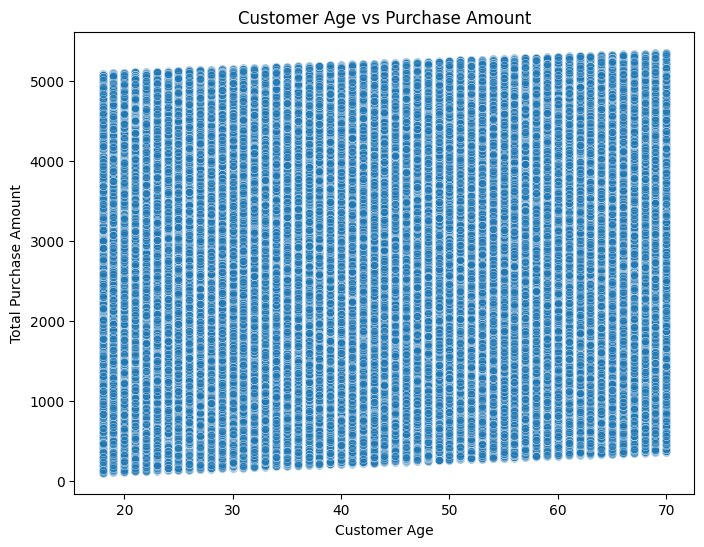

```python
plt.figure(figsize=(8,6))

sns.scatterplot(data=df, x='Age', y='Total Purchase Amount', alpha=0.5)

plt.title("Customer Age vs Purchase Amount")
plt.xlabel("Customer Age")
plt.ylabel("Total Purchase Amount")

plt.show()
```

### Insight: Customer Age vs Purchase Amount

The scatter plot illustrates the relationship between customer age and the total purchase amount. Each point represents an individual transaction made by a customer.

From the visualization, we can observe how purchase amounts are distributed across different age groups. If the points appear widely scattered without a clear upward or downward trend, it suggests that customer age may not strongly influence the amount spent on purchases.

This analysis helps businesses understand whether specific age groups tend to spend more than others. Such insights can assist in developing targeted marketing strategies, personalized promotions, and customer engagement initiatives aimed at different age segments.

### Business Interpretation

Analyzing the relationship between age and purchase amount helps businesses understand the spending behavior of different demographic groups. If certain age ranges show higher purchase values, companies can tailor marketing campaigns and product recommendations toward those customer segments to maximize revenue and customer satisfaction.

```python
snapshot_date = df['Purchase Date'].max() + pd.Timedelta(days=1)
```

```python
rfm = df.groupby('Customer ID').agg({
    'Purchase Date': lambda x: (snapshot_date - x.max()).days,
    'Customer ID': 'count',
    'Revenue': 'sum'
})

rfm.columns = ['Recency', 'Frequency', 'Monetary']

rfm.head()
```

| Customer ID | Recency | Frequency | Monetary |
| --- | --- | --- | --- |
| 1 | 289 | 3 | 5600 |
| 2 | 73 | 6 | 6459 |
| 3 | 223 | 4 | 3613 |
| 4 | 442 | 5 | 4339 |
| 5 | 425 | 5 | 2263 |

### RFM Calculation

Recency = Days since last purchase  
Frequency = Total number of purchases  
Monetary = Total spending by customer

```python
rfm['R_score'] = pd.qcut(rfm['Recency'], 4, labels=[4,3,2,1])
rfm['F_score'] = pd.qcut(rfm['Frequency'].rank(method="first"),4,labels=[1,2,3,4])
rfm['M_score'] = pd.qcut(rfm['Monetary'],4,labels=[1,2,3,4])

rfm['RFM_Score'] = rfm[['R_score','F_score','M_score']].sum(axis=1)
```

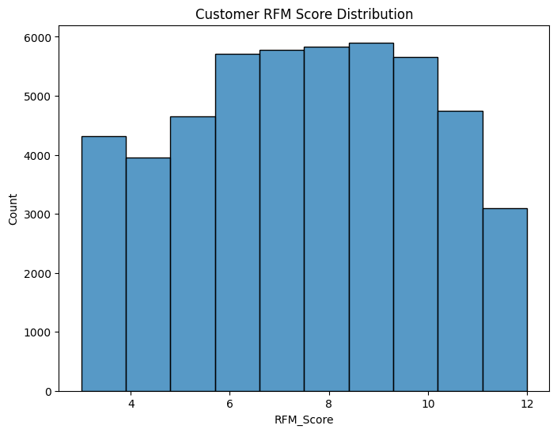

```python
plt.figure(figsize=(8,6))
sns.histplot(rfm['RFM_Score'], bins=10)
plt.title("Customer RFM Score Distribution")
plt.show()
```

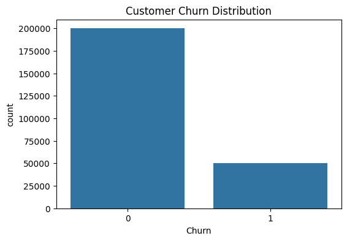

```python
plt.figure(figsize=(6,4))
sns.countplot(data=df, x='Churn')
plt.title("Customer Churn Distribution")
plt.show()
```

### Insight: Customer Churn Distribution

The bar chart shows the distribution of customers who have churned compared to those who remain active. Churn refers to customers who stop purchasing or discontinue their engagement with the business.

By examining this distribution, we can understand the proportion of customers that the business is losing over time. A higher number of churned customers may indicate potential issues related to customer satisfaction, product quality, pricing, or overall service experience.

Analyzing churn patterns helps businesses identify retention challenges and take proactive steps to reduce customer loss.

### Business Interpretation

Customer churn analysis is critical for maintaining long-term business growth. Retaining existing customers is generally more cost-effective than acquiring new ones.

If the dataset shows a significant number of churned customers, businesses should focus on improving customer engagement strategies such as loyalty programs, personalized promotions, better customer support, and targeted retention campaigns to reduce churn and increase customer lifetime value.

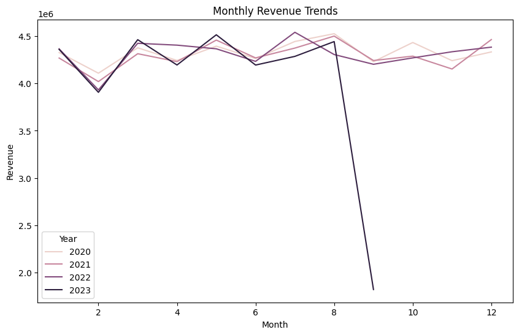

```python
monthly_sales = df.groupby(['Year','Month'])['Revenue'].sum().reset_index()

plt.figure(figsize=(10,6))
sns.lineplot(data=monthly_sales, x='Month', y='Revenue', hue='Year')
plt.title("Monthly Revenue Trends")
plt.show()
```

### Insight: Monthly Revenue Trends

The line chart illustrates the monthly revenue trends across different years. Each line represents a specific year, allowing us to compare how revenue changes from month to month.

From the visualization, we can observe patterns in customer purchasing behavior over time, such as periods of increased or decreased sales activity. Peaks in certain months may indicate seasonal demand, promotional campaigns, or increased customer engagement during specific periods.

Analyzing monthly revenue trends helps businesses understand sales performance over time and identify seasonal patterns that influence customer purchasing behavior.

### Business Interpretation

Understanding monthly revenue trends enables businesses to identify high-performing periods and potential seasonal patterns in sales. If certain months consistently generate higher revenue, companies can plan marketing campaigns, product launches, and promotional offers around those peak periods.

Similarly, months with lower revenue may require targeted marketing strategies, discounts, or promotional activities to boost customer engagement and sales performance.

## Key Insights

1. **Product Category Performance**

## Business Recommendations

1. **Focus on High-Revenue Product Categories**

   Businesses should prioritize marketing and inventory management for product categories that consistently generate higher revenue, ensuring product availability and targeted promotions.
2. **Strengthen Relationships with High-Value Customers**

   To reduce customer churn, businesses should focus on improving customer engagement through personalized communication, promotional offers, and proactive customer support.
5. **Leverage Sales Trend Insights for Strategic Planning**

   Monthly revenue trends should be used to plan marketing campaigns, promotional events, and inventory management strategies to maximize sales during peak periods and boost engagement during slower months.

## Conclusion

This project analyzed customer behavior using an e-commerce dataset to understand purchasing patterns, customer segmentation, and revenue trends.

The analysis involved several stages including data cleaning, exploratory data analysis, outlier detection, correlation analysis, feature engineering, and advanced visualizations. These steps helped uncover meaningful insights about customer purchasing behavior, product category performance, and sales trends.

Understanding these patterns allows businesses to implement data-driven strategies for improving customer retention, optimizing product offerings, and increasing overall revenue.

Overall, this analysis demonstrates how data analytics can support better business decision-making by transforming raw transactional data into actionable insights.